# Urinary Explainer

Jeffrey A. Walker

07 March, 2022

## Big Picture

Urine is **filtered** blood in which most of the good stuff is **reabsorbed** back into the blood, leaving the bad stuff to be **eliminated** in our urine. Because the kidney moves (a lot) of water out of the blood and then back into the blood, the kidney is also the organ used for water and electrolyte balance.

## Kidney function

The Kidney (and urinary system) has two major functions:

1. **clearance** of **endogenous** and **exogenous** metabolites. By “metabolites”, I mean products of metabolic reactions. Some of these metabolites we get in our diet (caffeine), [or are metabolic products from something in our diet, including drugs](https://en.wikipedia.org/wiki/Cytochrome_P450#Drug_metabolism) (this link is for your own learning and not for this unit). Some of these are byproducts of our own metabolism, for example, [ammonia from deamination of amino acids](https://en.wikipedia.org/wiki/Deamination) (this link is for your own learning and not for this unit) (the ammonia is converted to urea, which is both cleared by the kidney and important in water reabsorption in the collecting duct. This role of **Urea** is part of this unit).
2. **fluid, electrolyte, and pH balance**. The reason why we have a loop of Henle is because of this function. Otherwise, there would simply be something like a convoluted tubule that drained into a collecting duct (and of course the collecting duct would simply be a tube draining the nephron)

A minor function of the kidney is metabolism, in that kidney epithelial cells carry out some of the metabolic functions of liver hepatocytes. This is not important at the level of this class.

## Glomerular Filtration Rate (GFR)

Because of #1 above, the kidney **filters** a bunch of blood. How much?

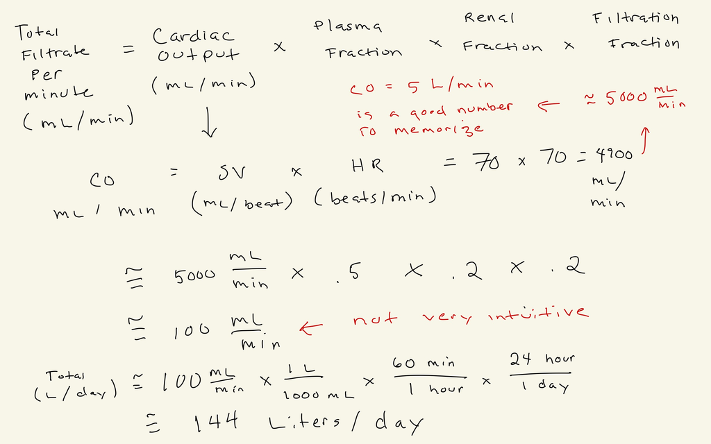

We make about 100 mL/minute of filtrate per minute. This is our **glomerular filtration rate** or **GFR**. This computation is an **approximation**. It is useful for thinking about GFR but GFR varies among individuals. 100 mL/minute might be useful in a clinical setting for someone familiar with GFR values but it is not very intuitive. To make this more intuitive, I’ve converted GFR to liters per day. Whoa! Our kidneys make 72 two-Liter coke bottles per day of filtrate, or about this much

[figure not shown]

This picture is striking and visually re-inforces how much of the water in this filtrate we reabsorb (98-99%).

### Capillary Blood pressure controls GFR

Filtration at the glomerulus is a specific example of **capillary exchange** more generally. Capillary exchange includes the transport of water across the epithelium due to the combined driving forces of fluid pressure forces and osmotic forces. Names for the fluid pressure force are “hydrostatic pressure” and “pressure potential”. Names for the osmotic force are “osmotic pressure”, “oncotic pressure”, and “solute potential”. The separate components of force are the Starling forces [BIO 223 specific]. Remember that in capillary exchange there is net fluid loss to the IF and that a lymph capillary takes this up and returns it back to the blood via the lymph vessels. Glomerular filtration differs in that the lumen of Bowman’s capsule is not IF and there is no lymph capillary. Instead, the fluid lost from the glomerular capillary is the filtrate. Remembering the principles of capillary exchange, increased capillary blood pressure will increase net fluid loss. So increasing glomerular capillary pressure increases GFR.

Glomerular capillary pressure is controlled by the **afferent arteriole** bringing blood to the glomerulus and the **efferent arteriole** draining the glomerulus. The afferent arteriole is more important. Let’s think about this. If the smooth muscle in the afferent arteriole contracts more, constricting the lumen more, pressure decreases downstream (there is less blood), which is the capillary. If the smooth muscle in the afferent arteriole contracts less, dilating the lumen, then pressure increases downstream (there is more blood).

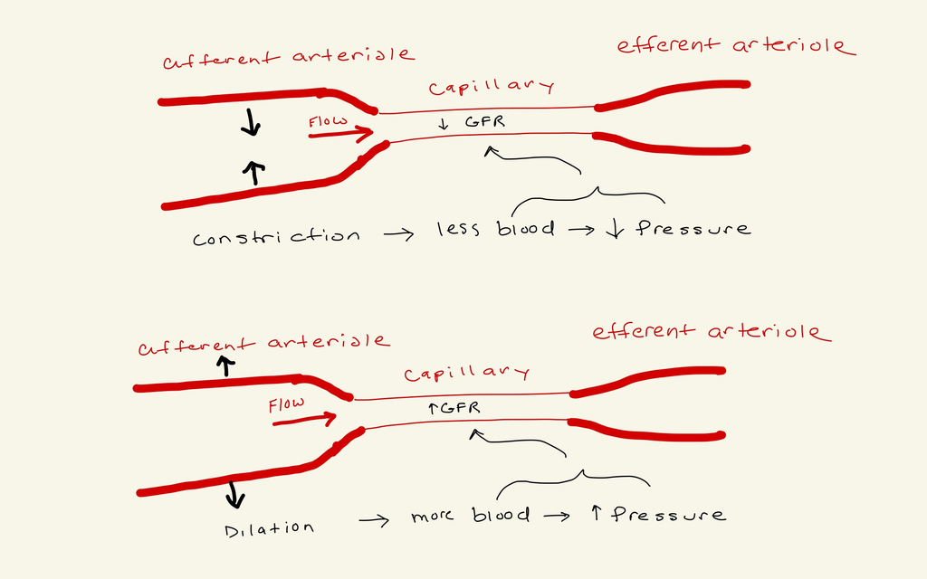

### Local control of GFR (autoregulation)

There is both systemic (signals from outside the arteriole/glomerulus) and local (signals from within the arteriole/glomerulus) control of GFR. Local control is also called **autoregulation**. This is not unique to the capillary of the glomerulus but it is most important here.

Our systemic blood pressure (BP) rises and falls throughout the day with both our activity level and our fluid balance. It is important for the GFR to remain pretty stable, that is, we don’t want GFR to increase when our blood pressure increases because we are running. And we don’t want our GFR to decrease because we are relaxing and reading a good novel. This stability is maintained by **autoregulation** or **local control** of GFR. Essentially,

- When BP increases, local control signals the afferent arteriole to constrict. This keeps capillary pressure lower than what it would be with the increased BP but no constriction and maintains capillary pressure at the stable level.
- When BP decreases, local control signals the afferent arteriole to relax, dilating the arteriole. This keeps capillary pressure higher than what it would be with the decreased BP but no dilation and maintains capillary pressure at the stable level.

#### Myogenic mechanism

The major *local control* mechanism is the **myogenic response**. The 30-second elevator pitch explanation is,

- increased systemic BP stretches the wall of the afferent arteriole. In response, the smooth muscle contracts, decreasing glomerular capillary pressure downstream and maintaining GFR.
- decreased systemic BP compresses the wall of the afferent arteriole. In response, the smooth muscle relaxes, increasing glomerular capillary pressure downstream and maintaining GFR.

Stretch-contract. Shorten-relax. The cell sensing the stretched/shortened wall mechanism is still controversial. It could be the smooth muscle cells sensing the stretch or it could be the endothelial cells that sense the stretch (or both).

#### Tubuloglomerular feedback

The other local control mechanism is **tuberoglomerular feedback** but this is more important in systemic control of body fluid volumes and systemic blood pressure. The important anatomy is the **juxtaglomerular complex**, which occurs where the **distal convoluted tubule** runs adjacent to the **afferent arteriole**. Specialized epithelial cells of the DCT are called the **macula densa (MD) cells**. Specialized smooth muscle cells of the afferent arteriole are called the **juxtaglomerular (JG) cells**. MD cells sense Na+ and signal smooth muscle to contract. JG cells secrete **renin**, which is part of systemic BP/fluid balance control sa we will return to this. The 30-second elevator pitch of the MD mechanism of local control is,

- increased systemic BP increases GFR until local control kicks in. Increased GFR increases Filtrate. With more filtrate there is less time to re-absorb Na+ and H2O in the PCT. The high Na+ load is sensed by the MD cells of the DCT. These signal the smooth muscle cells of the afferent arteriole to contract, reducing glomerular capillary pressure and returning GFR back to normal.
- decreased systemic BP decreases GFR until local control kicks in. Decreased GFR decreases Filtrate. With less filtrate, more Na+ and H2O are reabsorbed by the PCT. The low Na+ load is sensed by the MD cells of the DCT. These signal the smooth muscle cells of the afferent arteriole to relax, increasing glomerular capillary pressure and returning GFR back to normal.

## Hormonal control of water reabsorbtion

We make about 150 liters of filtrate per day (lets use easy numbers). Let’s say we urinate about 1.5 liters per day or 1%. Maybe if we’re overhydrated we’ll urinate 2.5 liters or underhydrated we’ll urinate .5 liters. So we eliminate about 0.3 to 1.6% of our daily filtrate. This variation in urine volume is due to the hormonal control of water reabsorption. If we are de-hydrated, we reabsorb the extra 0.7% and if we are overhydrated we eliminate the extra 0.6%. The other ~ 99% of the water that is reabsorbed is not under hormonal control. It is automatic. Most of this automatic H2O reabsorption occurs in the PCT. Some occurs in the Loop of Henle. And some in the first part of the DCT. By the time the filtrate gets to the distal part of the DCT, it’s close to the volume of urine that we make. If we’re dehydrated, we’ll reabsorb much of this in the DCT and especially the **collecting duct** and pee less. If we’re overhydrated, we won’t reabsorb much of this but will pee it out. Let’s suss this out.

### Reabsorption in the collecting duct

#### The solute concentration gradient from base to apex of the renal pyramid is critical for this reabsorption.

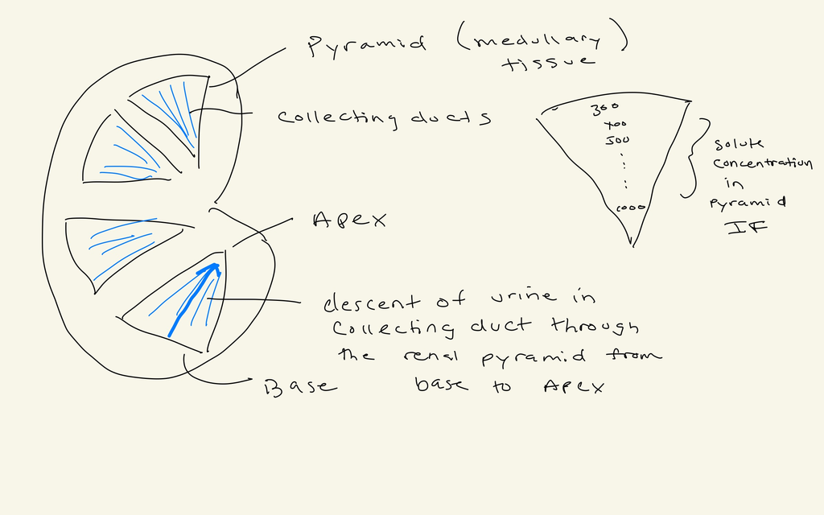

#### The big picture

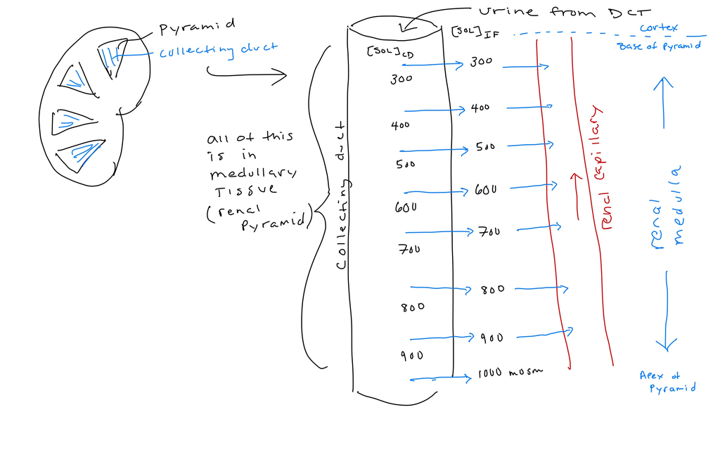

In the picture above, I’ve labeled the solute concentration in mOsm (miliosmoles) in the urine inside the CD and in the IF of the pyramid (medullary tissue). The gradient in the IF of the pyramid (outside of the CD) is created and maintained by the Loop of Henle. The filtrate entering the distal DCT/collecting duct is dilute (low solute concentration). What happens as the filtrate enters the CD? These are the extremes:

- if we have low systemic fluid levels (dehydrated) then **antidiuretic hormone (ADH)** signals increased **aquaporin** (protein channels that transport H2O) expression in the epithelium of the CD. This makes the CD permeable to water and water is reabsorbed, so we don’t lose water.
- if we have high systemic fluid levels (over-hydrated) then there is no ADH signaling and our aquaporin expression is downregulated. The CD epithelium is not permeable to water and the filtrate that enters the CD exits the CD to the bladder.

#### So why have a base-to-apex concentration gradient in the IF?

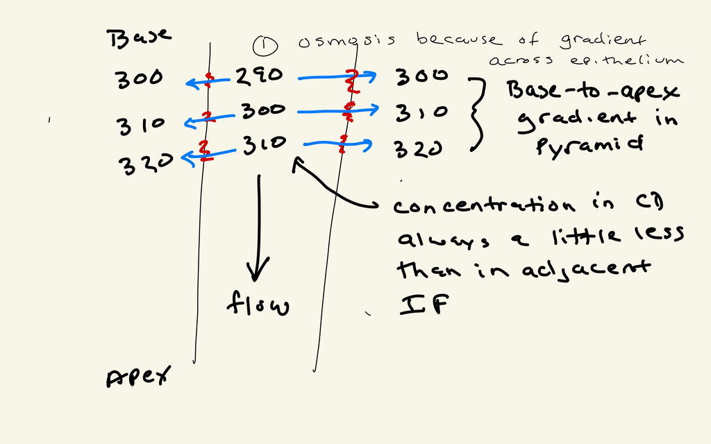

Here is what happens if the epithelium is permeable to H2O:

1. As fluid enters the CD, the solute concentration in the IF is higher than in the CD so water moves from CD to IF (and into vasa recta capillary) by osmosis. This makes the concentration of the CD fluid increase – it actually equilibrates with the fluid in the IF right outside of the tube.
2. But, as the fluid descends in the CD, it quickly goes back out of equilibrium because the osmolality of the IF is even higher. So more water moves into the IF by osmosis, which increases the concentration of the urine in the CD.
3. And, as the fluid descends in the CD even more, it again goes back out of equilibrium because the osmolality of the IF is even higher. So more water moves into the IF by osmosis, which increases the concentration of the urine in the CD.

If there weren’t a base-to-apex solute concentration gradient in the IF, that is, if the concentration in the IF were the same as elsewhere in the body (~ 300 mOsm), then the fluid in the CD would quickly reach equilibrium with the IF and there could be no more water reabsorption.

**Conception/Misconception** – this is more of a pet peeve than a misconception. Notice that a consequence of hormonally controlled water reabsorption in the Collecting Duct is that the urine gets more concentrated. Physiologists refer to this process described as a **concentrating mechanism**. I have two issues with this. First, the “goal” of this mechanism is not to concentrate the urine but to reabsorb water. The focus should be on reabsorption and not “concentrating the urine”. Second, humans are very familiar with concentrating mechanisms – when we make frosting for cookies, we add dye, stir, and assess the color. If its not colored enough, we add more dye. When we make Tang or Folger’s instant coffee (who does this?) we add the tang/coffee crystals to the water and stir. Then we taste. If it’s not tasty enough, we add more crystals. So humans concentrate stuff by adding the solute. The mechanism in the collecting duct is the opposite. Solutes aren’t added. Instead, water is removed. So focus on the removal!